# Forecasting_Regression

Bhoomika John Pedely

2023-08-21

This is a mini-project inspired by the ‘Business Decision Algorithm’ class during my MSBA program. I am solving a forecasting problem where I will be using a multiple regression model to predict the outcome, Gas Demand.

The data can be accessed at the given url: “http://data.mishra.us/files/utah_idaho_gas.csv”.

#### Loading the data

```r
gas_data <- read.csv(url("http://data.mishra.us/files/utah_idaho_gas.csv"))
```

### Explanatory Analytics

#### Exploring the data

```r
str(gas_data)
```

```
## 'data.frame':    120 obs. of  12 variables:
##  $ X                    : int  1 2 3 4 5 6 7 8 9 10 ...
##  $ state                : chr  "Idaho" "Idaho" "Idaho" "Idaho" ...
##  $ year                 : int  1994 1994 1994 1994 1995 1995 1995 1995 1996 1996 ...
##  $ quarter              : int  1 2 3 4 1 2 3 4 1 2 ...
##  $ gasoline_demand      : num  3.41 3.96 4.07 3.42 3.34 ...
##  $ federal_tax          : num  18.4 18.4 18.4 18.4 18.4 ...
##  $ price                : num  133 138 153 149 140 ...
##  $ unemployment         : num  5.6 5.47 5.4 5.3 5.27 ...
##  $ percapita_income     : num  23292 23748 23825 23918 24108 ...
##  $ population           : num  1126954 1136047 1145140 1153186 1161231 ...
##  $ public_transport_fund: num  4 4 4 4 4 4 4 4 9 9 ...
##  $ lag_demand           : num  NA 3.41 3.96 4.07 3.42 ...
```

```r
summary(gas_data)
```

```
##        X             state                year         quarter
##  Min.   :  1.00   Length:120         Min.   :1994   Min.   :1.00
##  1st Qu.: 30.75   Class :character   1st Qu.:1997   1st Qu.:1.75
##  Median : 60.50   Mode  :character   Median :2001   Median :2.50
##  Mean   : 60.50                      Mean   :2001   Mean   :2.50
##  3rd Qu.: 90.25                      3rd Qu.:2005   3rd Qu.:3.25
##  Max.   :120.00                      Max.   :2008   Max.   :4.00
##
##  gasoline_demand  federal_tax        price        unemployment
##  Min.   :3.006   Min.   :18.30   Min.   :121.4   Min.   :2.433
##  1st Qu.:3.531   1st Qu.:18.40   1st Qu.:147.2   1st Qu.:3.458
##  Median :3.808   Median :18.40   Median :164.2   Median :4.367
##  Mean   :3.783   Mean   :18.39   Mean   :183.1   Mean   :4.274
##  3rd Qu.:4.022   3rd Qu.:18.40   3rd Qu.:201.9   3rd Qu.:5.108
##  Max.   :4.552   Max.   :18.40   Max.   :360.2   Max.   :5.900
##
##  percapita_income   population      public_transport_fund   lag_demand
##  Min.   :21857    Min.   :1126954   Min.   :  0.00        Min.   :3.006
##  1st Qu.:25079    1st Qu.:1319819   1st Qu.:  4.00        1st Qu.:3.535
##  Median :27791    Median :1730752   Median : 11.02        Median :3.810
##  Mean   :27311    Mean   :1815187   Mean   : 77.89        Mean   :3.789
##  3rd Qu.:29397    3rd Qu.:2282450   3rd Qu.: 97.00        3rd Qu.:4.025
##  Max.   :31284    Max.   :2741650   Max.   :499.00        Max.   :4.552
##                                                           NA's   :1
```

```r
head(gas_data)
```

```
##   X state year quarter gasoline_demand federal_tax    price unemployment
## 1 1 Idaho 1994       1        3.414869        18.4 132.6184     5.600000
## 2 2 Idaho 1994       2        3.956263        18.4 138.2616     5.466667
## 3 3 Idaho 1994       3        4.067451        18.4 152.5863     5.400000
## 4 4 Idaho 1994       4        3.415062        18.4 149.0970     5.300000
## 5 5 Idaho 1995       1        3.339215        18.4 139.6282     5.266667
## 6 6 Idaho 1995       2        3.809535        18.4 143.7849     5.200000
##   percapita_income population public_transport_fund lag_demand
## 1         23291.60    1126954                     4         NA
## 2         23747.81    1136047                     4   3.414869
## 3         23825.17    1145140                     4   3.956263
## 4         23917.59    1153186                     4   4.067451
## 5         24108.47    1161231                     4   3.415062
## 6         24057.64    1169277                     4   3.339215
```

#### Univariate Linear Regression Model: gasoline_demand ~ unemployment

Visualizing the influence of unemployment rate on gasoline demand by first drawing a scatter plot between unemployment rate and gasoline demand. Then, drawing the line of best fit through the scatter plot.

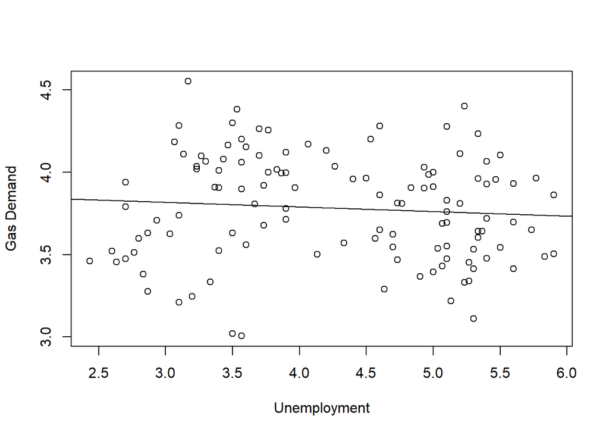

```r
fit <- lm(gasoline_demand~unemployment, data=gas_data)
plot(gas_data$unemployment, gas_data$gasoline_demand,xlab="Unemployment",
ylab="Gas Demand")
abline(fit)
```

```r
library(effects)
```

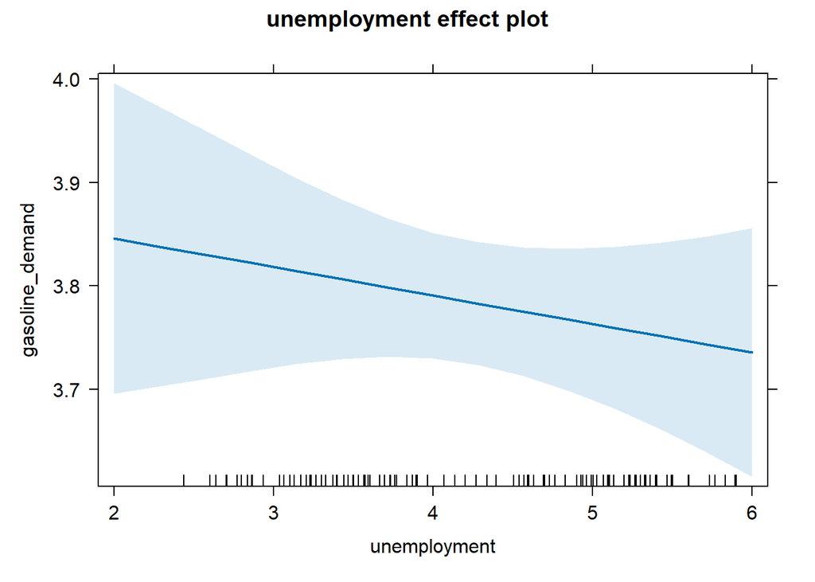

```r
allEffects.fit <- allEffects(fit)
plot(allEffects.fit)
```

```r
summary(fit)
```

```
##
## Call:
## lm(formula = gasoline_demand ~ unemployment, data = gas_data)
##
## Residuals:
##     Min      1Q  Median      3Q     Max
## -0.7968 -0.2351  0.0243  0.2275  0.7389
##
## Coefficients:
##              Estimate Std. Error t value Pr(>|t|)
## (Intercept)   3.90085    0.13463  28.975   <2e-16 ***
## unemployment -0.02757    0.03073  -0.897    0.372
## ---
## Signif. codes:  0 '***' 0.001 '**' 0.01 '*' 0.05 '.' 0.1 ' ' 1
##
## Residual standard error: 0.3232 on 118 degrees of freedom
## Multiple R-squared:  0.006774,   Adjusted R-squared:  -0.001643
## F-statistic: 0.8048 on 1 and 118 DF,  p-value: 0.3715
```

The coefficient estimate of the predictor unemployment is -0.02757. This means that when unemployment rate falls by 1 unit, gasoline demand increases by 0.02 unit (here the unit of consumption is barrels per capita per quarter).

The t-statistic -0.89 and the p-value 0.372 indicates that unemployment rate does not have a significant influence on gasoline demand.

```r
#Checking if the assumption that residuals are distributed normally is true with this dataset. A means of residuals closer to 0 would suggest that it is.
mean(fit$residuals)
```

```
## [1] -6.312767e-18
```

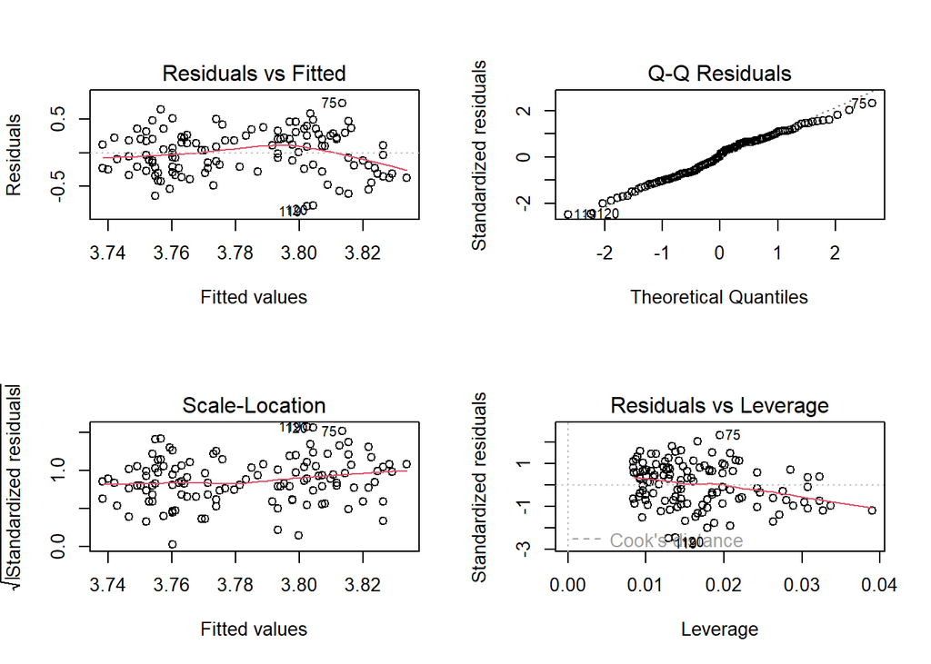

```r
#Checking for homoscedasticity
par(mfrow=c(2, 2))
plot(fit)
```

```r
#Checking for autocorrelation using Durbin Watson test. Values between 0 and 2 indicate positive correlation and between 2 and 4 indicate negative correlation.
lmtest::dwtest(fit)
```

```
##
##  Durbin-Watson test
##
## data:  fit
## DW = 1.0401, p-value = 3.485e-08
## alternative hypothesis: true autocorrelation is greater than 0
```

#### Linear Multiple Regression

Influence of disposable income per capita (in dollars), population, and total investment by state and federal fuel tax rate, state unemployment rate, federal government in state’s public transit and gasoline prices as the predictor variables on gas demand.

```r
fit.multiple <- (lm(gasoline_demand~federal_tax+price+unemployment+percapita_income+
population+public_transport_fund+lag_demand, data=gas_data))

summary(fit.multiple)
```

```
##
## Call:
## lm(formula = gasoline_demand ~ federal_tax + price + unemployment +
##     percapita_income + population + public_transport_fund + lag_demand,
##     data = gas_data)
##
## Residuals:
##      Min       1Q   Median       3Q      Max
## -0.59431 -0.18836 -0.01247  0.19196  0.66444
##
## Coefficients:
##                         Estimate Std. Error t value Pr(>|t|)
## (Intercept)            1.284e+01  1.564e+01   0.821  0.41367
## federal_tax           -4.935e-01  8.599e-01  -0.574  0.56717
## price                 -4.447e-04  8.549e-04  -0.520  0.60397
## unemployment          -9.440e-02  3.568e-02  -2.646  0.00934 **
## percapita_income      -2.562e-05  1.726e-05  -1.484  0.14067
## population             1.521e-07  7.177e-08   2.120  0.03624 *
## public_transport_fund -1.158e-03  3.537e-04  -3.274  0.00142 **
## lag_demand             2.702e-01  9.132e-02   2.959  0.00377 **
## ---
## Signif. codes:  0 '***' 0.001 '**' 0.01 '*' 0.05 '.' 0.1 ' ' 1
##
## Residual standard error: 0.2672 on 111 degrees of freedom
##   (1 observation deleted due to missingness)
## Multiple R-squared:  0.3542, Adjusted R-squared:  0.3135
## F-statistic: 8.697 on 7 and 111 DF,  p-value: 1.746e-08
```

### Predictive Analytics

```r
library(caret)
```

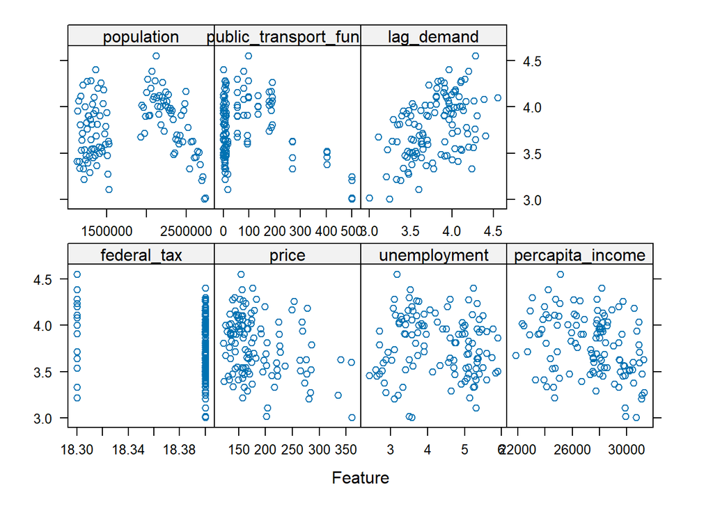

```r
macro <- gas_data

#Looking at each predictor individually
featurePlot(x=macro[,6:12], y=macro[,5])
```

```r
#Splitting the data
set.seed(1234)
datasplit <- createDataPartition(macro$gasoline_demand, p = 0.7,list=FALSE)
trainData <- macro[datasplit,]
testData <- macro[-datasplit,]
```

```r
#Training the model
lmregression <- train(gasoline_demand ~ federal_tax+price+unemployment+
percapita_income+ population+public_transport_fund
+lag_demand, data = trainData, method = "lm",
na.action=na.exclude)
summary(lmregression)
```

```
##
## Call:
## lm(formula = .outcome ~ ., data = dat)
##
## Residuals:
##      Min       1Q   Median       3Q      Max
## -0.55916 -0.18570 -0.00966  0.14629  0.67269
##
## Coefficients:
##                         Estimate Std. Error t value Pr(>|t|)
## (Intercept)            1.429e+01  1.914e+01   0.747  0.45760
## federal_tax           -5.568e-01  1.060e+00  -0.525  0.60092
## price                 -6.962e-04  9.727e-04  -0.716  0.47635
## unemployment          -1.349e-01  4.487e-02  -3.006  0.00359 **
## percapita_income      -1.920e-05  2.294e-05  -0.837  0.40524
## population             1.365e-07  8.950e-08   1.525  0.13144
## public_transport_fund -1.465e-03  4.497e-04  -3.257  0.00168 **
## lag_demand             2.186e-01  1.191e-01   1.836  0.07030 .
## ---
## Signif. codes:  0 '***' 0.001 '**' 0.01 '*' 0.05 '.' 0.1 ' ' 1
##
## Residual standard error: 0.2742 on 76 degrees of freedom
## Multiple R-squared:  0.3625, Adjusted R-squared:  0.3037
## F-statistic: 6.173 on 7 and 76 DF,  p-value: 9.89e-06
```

```r
#Predicting and measuring performance on test
predictions <-predict(lmregression, newdata=testData)
postResample(predictions, testData$gasoline_demand)
```

```
##      RMSE  Rsquared       MAE
## 0.2917214        NA 0.2409831
```

RMSE is given in terms of the units of the outcome, which is gasoline_demand. Since, gasoline_demand ranges from 3 to 5, 0.29 is a good RMSE. The lower, the better.

```r
#Checking for multicolliniearity among all the predictor variables using Variance Inflation Factor, VIF.
fit_3 <- lm(gasoline_demand~federal_tax+price+unemployment+percapita_income+
population+public_transport_fund+lag_demand, data=gas_data)
car::vif(fit_3)
```

```
##           federal_tax                 price          unemployment
##              1.279434              3.390163              1.940386
##      percapita_income            population public_transport_fund
##              2.909806              2.330705              3.168118
##            lag_demand
##              1.380877
```

VIF values of less than 5 are considered fine.